# Replicación: "How Robust Are SVARs at Measuring Monetary Policy in Small Open Economies?"

Carrillo & Elizondo (2015/2018) • Journal of Empirical Finance • México • VAR(3) mensual • Ene 2001 – Mar 2014

📋 Scorecard de Replicación

§1 — Descripción de Datos

📄 Paper Original (C&E 2015/2018)

🔬 Replicación (Este trabajo)

**Muestra:** Ene 2001 – Mar 2014 • T = 159 • Frecuencia mensual  
**Endógenas (Y<sub>t</sub>):**

- y<sub>t</sub> − ȳ<sub>t</sub>: Output gap (IGAE)
- π<sub>t</sub> − π̄<sub>t</sub>: Core CPI inflation gap
- π<sub>t</sub><sup>p</sup> − π̄<sub>t</sub>: PPI inflation gap
- Δq<sub>t</sub>: Real ER depreciation (21 trading partners, IFS)
- i<sub>t</sub> − π̄<sub>t</sub>: Nom. interest rate gap (Cetes 28d)
- Δm<sub>t</sub> − π̄<sub>t</sub>: Money growth gap (M2)

**Exógenas (Z<sub>t</sub>):**

- y<sub>t</sub><sup>us</sup> − ȳ<sub>t</sub><sup>us</sup>: US output gap (INDPRO, HP)
- π<sub>t</sub><sup>us</sup>: US PCE inflation
- π<sub>t</sub><sup>crb</sup>: CRB commodity price inflation

**Transformaciones:** log-dif ×1200, filtro HP (λ=129,600), ajuste estacional

π̄<sub>t</sub> = tendencia HP de inflación subyacente = ancla nominal

⚠ Diferencia TCR: Banxico SR15997 (49 socios) vs. paper (21 socios, IFS).

Corr(y_mx, y_us) en muestra = 0.9 (paper: 0.86)

Figure C.3: Original data (with HP trend)

No disponible digitalmente — ver PDF p.50 (Appendix C)

Equivalente Fig. C.3: Series originales + tendencia HP

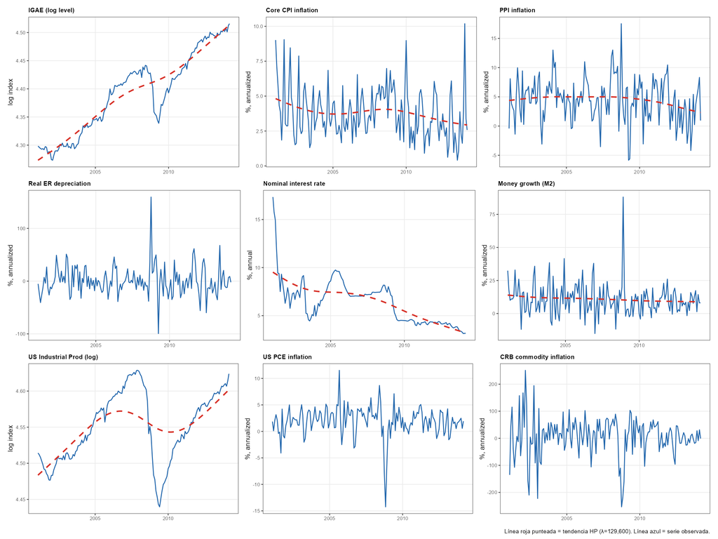

Línea roja punteada = tendencia HP (λ=129,600)

§2 — Estadísticos Descriptivos

📄 Paper Original (C&E 2015/2018)

🔬 Replicación (Este trabajo)

Tabla A1 (Apéndice C)

El paper no reporta una tabla explícita de estadísticos descriptivos en el cuerpo principal. La Figura C.3 muestra visualmente las propiedades de las series.

Rangos aproximados del paper (Fig. 6 y C.3):  
• Output gap: ±4% pts  
• Core π gap: ±2 pp  
• PPI gap: ±10 pp  
• TCR dep: ±10%  
• Interest rate gap: 0–8 pp  
• M2 gap: ±4 pp

Estadísticos descriptivos calculados

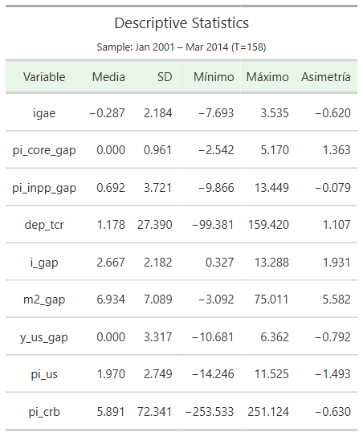

§3 — Diagnósticos Estadísticos

📄 Paper Original (C&E 2015/2018)

🔬 Replicación (Este trabajo)

**Raíces unitarias (Apéndice C):** Todas las variables rechazan H₀: raíz unitaria al 5%.  
Joint unit-root tests (Levin-Lin-Chu, Breitung) también rechazados.

Con muestras pequeñas, los tests de raíz unitaria tienen bajo poder. La teoría económica apoya estacionariedad de las series en gap/tasa de crecimiento.

Tests individuales (ADF + PP)

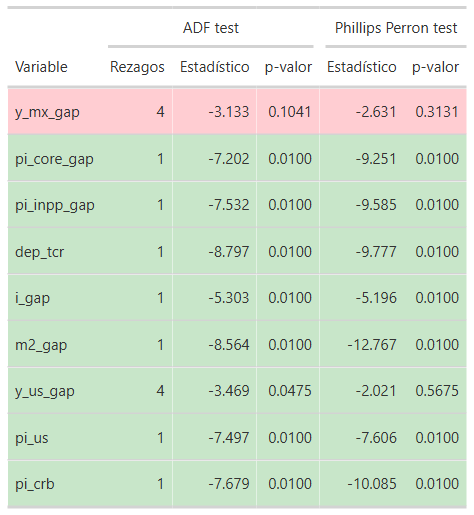

| Test | Estadístico | p-valor | Decisión vs Paper |
| --- | --- | --- | --- |
| Levin-Lin-Chu (2002) | -4.6285 | 0 | ✓ Rechaza H0 / Paper: Rechaza H0 |
| Im-Pesaran-Shin (2003) | -16.3579 | 0 | ✓ Rechaza H0 / Paper: Rechaza H0 |

N=9 series × T=159 obs. H₀: raíz unitaria común. Selección de lags: AIC.

**Selección de rezagos:**  
SIC → p = 1 • AIC → p = 2 • LR test → p = 3  
Hatemi & Hacker (2009): LR desempata cuando SIC y AIC difieren.  
**Decisión: p = 3**

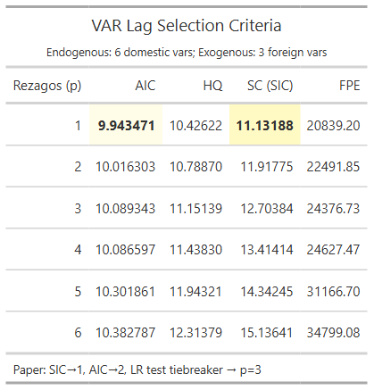

VARselect con exógenas block-exógenas. Paper: SIC→1, AIC→2, LR→3.

**Estabilidad del VAR:** Todas las raíces del polinomio característico dentro del círculo unitario ✓  
**Autocorrelación (Ljung-Box Q, 3 lags):**  
Solo la ecuación del output gap rechaza H₀ de no autocorrelación.  
Requeriría 12 lags para no rechazar → ~500 parámetros con T=153.  
**Decisión: mantener p=3**

**Estabilidad:**

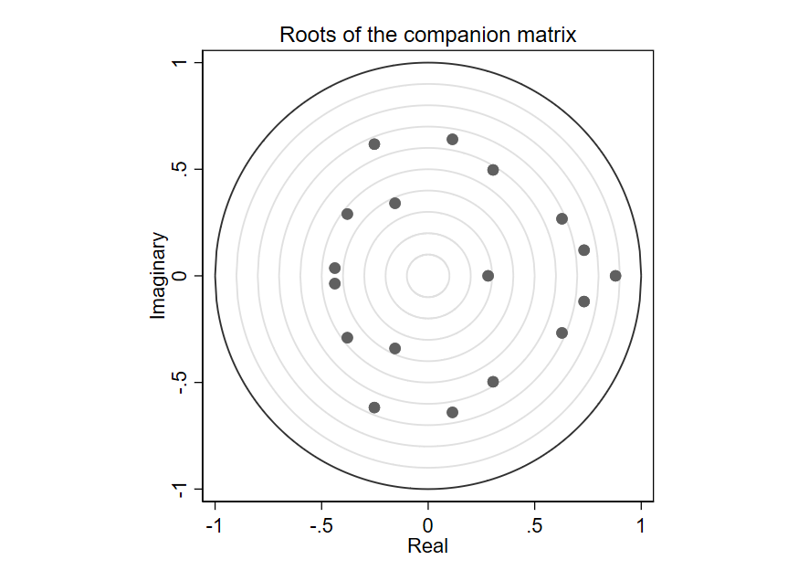

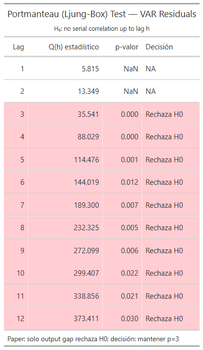

§4 — Estimación de β<sub>lower</sub> (Ecuación 11)

📄 Paper Original (C&E 2015/2018)

🔬 Replicación (Este trabajo)

**Regresión:** Δπ<sub>t</sub> = β₀ + β<sub>i</sub>·Δi<sub>t</sub> + β<sub>ii</sub>·D<sub>t</sub>·Δi<sub>t</sub> + ω<sub>t</sub>  
donde ω<sub>t</sub> ~ ARMA(1,2) y D<sub>t</sub> = 1 si signos opuestos.

| Parámetro | Valor paper |
| --- | --- |
| β̂⁻ (punto) | −0.035 |
| β̂⁻<sub>lower</sub> (IC 95%) | −0.7 |
| Restricción aug. | β̂<sub>lower</sub>·Δi ≤ Δπ ≤ 0 |

| Parámetro | Replicación | Paper | Match |
| --- | --- | --- | --- |
| β̂⁻ (punto) | -0.4012 | −0.035 | ~ |
| β̂⁻<sub>lower</sub> (IC 95%) | -0.7208 | −0.700 | ✓ |
| Método | OLS+NW (C&E 2015) |  |  |

§5 — Restricciones de Exclusión — Figura 7

📄 Paper Original (C&E 2015/2018)

🔬 Replicación (Este trabajo)

Figura 7 del paper (p.27)

No disponible digitalmente — ver PDF p.27

**Hallazgos paper:** VAR simple: output incluso sube post-choque; inflación no significativa. VAR w/exo: output cae moderadamente, inflación cae en patrón hump-shaped (pico ~6 meses). No descarta price puzzle.  
Bootstrap: 2,000 draws. IC: 68%. n=6 endógenas, p=3.

Figura 7 — Replicación (MATLAB, Sección 4B)

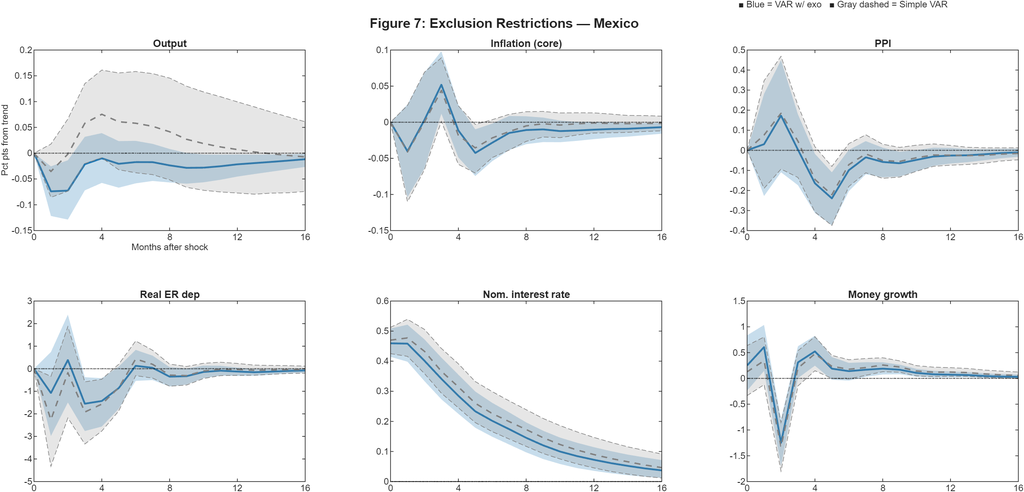

Bootstrap: 2,000 draws. IC: 68% (percentiles 16-84). Misma estructura que paper.

§6 — Restricciones de Signo — Figura 8

📄 Paper Original (C&E 2015/2018)

🔬 Replicación (Este trabajo)

Figura 8 (p.30)

No disponible digitalmente — ver PDF p.30

**Panel superior (Standard):** Mediana de elasticidad de inflación = −2.5 (simple) / −2.0 (w/exo).  
VAR w/exo principalmente reduce bandas para output gap.  
**Panel inferior (Augmented):** Mediana de elasticidad cae a −0.35. Price puzzle ocurre con menor probabilidad. Pico de inflación: dentro de 6 meses, no en el impacto.

Figura 8 — Replicación (MATLAB)

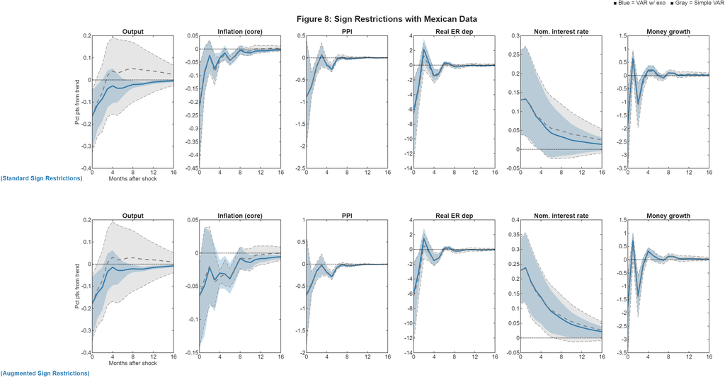

§7 — Comparación de Estrategias — Figura 9

📄 Paper Original (C&E 2015/2018)

🔬 Replicación (Este trabajo)

Figura 9 (p.33)

No disponible digitalmente — ver PDF p.33

**Panel superior (Exclusion vs Augmented):** Todas las variables responden en la misma dirección tras algunos períodos. Exclusion: respuestas más pequeñas para output, π, PPI, TCR. Exclusion: respuesta mayor para tasa de interés.  
**Panel inferior (Standard vs Augmented):** Única diferencia relevante: impact response de inflación. Standard: mediana = −2.5; Augmented: mediana = −0.35.

Figura 9 — Replicación (MATLAB)

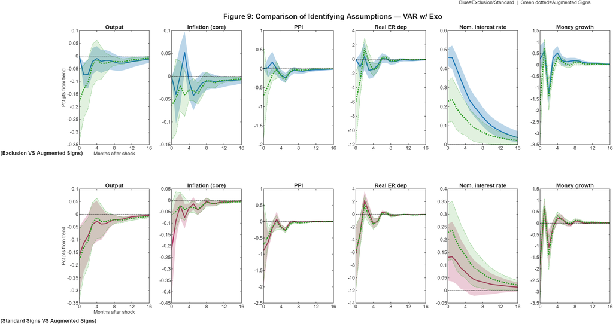

VAR con exógenas solamente. Cholesky = azul sólido; Augmented = verde punteado. Standard = magenta; Augmented = verde.

§8 — Resumen Cuantitativo: Paper vs. Replicación

§8 Impact Responses (h=0): Paper vs. Replicación

Choque monetario contractivo (i_gap aumenta 1 pp)

| Variable | Exclusion (Cholesky) Paper | Exclusion (Cholesky) Replicación | Standard Signs Paper | Standard Signs Replicación | Augmented Signs Paper | Augmented Signs Replicación |
| --- | --- | --- | --- | --- | --- | --- |
| Output | ~0 | 0.000 | − | −0.170 | − | −0.183 |
| Core inflation | ~0 | 0.000 | − | −0.226 | ≈0 pequeño | −0.064 |
| PPI | ~0 | 0.000 | libre | −0.954 | libre | −0.797 |
| Real ER dep | ~0 | 0.000 | − | −6.326 | − | −6.071 |
| Nom. interest rate | +0.47 approx | +0.466 | + | +0.129 | + | +0.228 |
| Money growth | +0.31 approx | +0.313 | − | −1.961 | − | −1.897 |

Cholesky h=0: por definición del ordenamiento, output/π no reaccionan en impacto.  
Standard/Augmented: mediana de modelos aceptados. Signs paper: dirección impuesta.

**Principales diferencias:**